# Importing Required Libraries

# Random Forest Classifier

```python
rfc=RandomForestClassifier(oob_score=True)
```

```python
rfc.fit(xtrain,ytrain)
```

```
RandomForestClassifier(oob_score=True)
```

```python
y_predict3=rfc.predict(xtest)
```

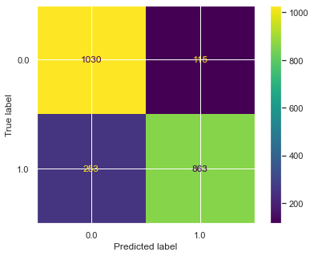

```python
sns.set(rc={'figure.figsize':(7,5)})
plot_confusion_matrix(rfc,xtest,ytest)
plt.show()
```

```python
rfc.oob_score_
```

```
0.8253366205196283
```

```python
print(classification_report(ytest,y_predict3))
```

```
              precision    recall  f1-score   support

         0.0       0.80      0.90      0.85      1145
         1.0       0.88      0.77      0.82      1116

    accuracy                           0.84      2261
   macro avg       0.84      0.84      0.84      2261
weighted avg       0.84      0.84      0.84      2261
```

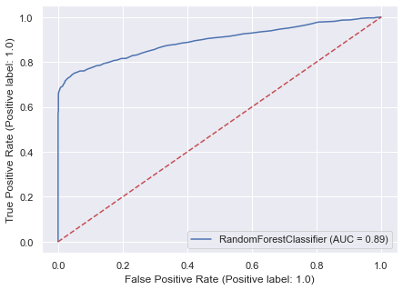

```python
# Plotting ROC curve
plot_roc_curve(rfc,xtest,ytest)
plt.plot([0,1],[0,1],color='r',ls='--')
plt.show()
```

```python
roc_auc_score(ytest,rfc.predict_proba(xtest)[:,1])
```

```
0.8939334178522796
```

```python
ls = []
for w in range(20,500,10):
    ran = RandomForestClassifier(oob_score=True,n_estimators=w,random_state=69)
    ran.fit(xtrain,ytrain)
    oob=ran.oob_score_
    ls.append((oob,w))
```

```python
print(max(ls))
```

```
(0.8327327896832922, 490)
```

```python
imp1=[]
for i in rfc.estimators_:
    imp1.append(i.feature_importances_)
```

```python
feat_mean=np.mean(imp1,axis=0)
feat=pd.DataFrame({'features':xtrain.columns,'imp_score':feat_mean})
feat.sort_values(by='imp_score',ascending=False)
```

|  | features | imp_score |
| --- | --- | --- |
| 1 | Disbursed_Amount | 0.171401 |
| 2 | ltv | 0.169833 |
| 0 | Loan_Id | 0.163129 |
| 3 | PERFORM_CNS.SCORE | 0.132267 |
| 10 | Employment_Type_Self employed | 0.063071 |
| 5 | Region_Name_East | 0.057568 |
| 7 | Region_Name_South | 0.055331 |
| 8 | Region_Name_West | 0.050671 |
| 9 | Employment_Type_Salaried | 0.048738 |
| 4 | NO.OF_INQUIRIES | 0.044778 |
| 6 | Region_Name_North | 0.028704 |
| 11 | Employment_Type_Unknown | 0.014510 |

# Bagging Classifier

```python
bgc=BaggingClassifier(oob_score=True)
```

```python
bgc.fit(xtrain,ytrain)
```

```
BaggingClassifier(oob_score=True)
```

```python
y_predict4=bgc.predict(xtest)
```

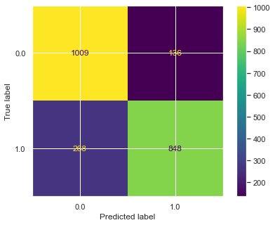

```python
sns.set(rc={'figure.figsize':(7,5)})
plot_confusion_matrix(bgc,xtest,ytest)
plt.show()
```

```python
bgc.oob_score_
```

```
0.7834249952588659
```

```python
print(classification_report(ytest,y_predict4))
```

```
              precision    recall  f1-score   support

         0.0       0.79      0.88      0.83      1145
         1.0       0.86      0.76      0.81      1116

    accuracy                           0.82      2261
   macro avg       0.83      0.82      0.82      2261
weighted avg       0.83      0.82      0.82      2261
```

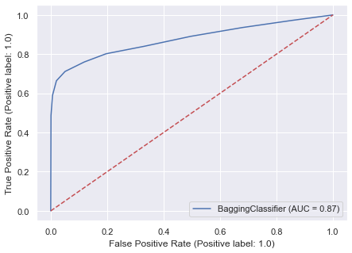

```python
# Plotting ROC curve
plot_roc_curve(bgc,xtest,ytest)
plt.plot([0,1],[0,1],color='r',ls='--')
plt.show()
```

```python
ls1 = []
for w in range(20,300,10):
    bag = BaggingClassifier(base_estimator=DecisionTreeClassifier(),oob_score=True,n_estimators=w)
    bag.fit(xtrain,ytrain)
    oob=bag.oob_score_
    ls1.append((oob,w))
```

```python
print(max(ls1))
```

```
(0.8310259814147544, 260)
```

```python
imp=[]
for i in bgc.estimators_:
    imp.append(i.feature_importances_)
```

```python
feat_mean=np.mean(imp,axis=0)
feat=pd.DataFrame({'features':xtrain.columns,'imp_score':feat_mean})
feat.sort_values(by='imp_score',ascending=False)
```

|  | features | imp_score |
| --- | --- | --- |
| 1 | Disbursed_Amount | 0.169456 |
| 0 | Loan_Id | 0.165401 |
| 2 | ltv | 0.160712 |
| 3 | PERFORM_CNS.SCORE | 0.143924 |
| 10 | Employment_Type_Self employed | 0.095702 |
| 8 | Region_Name_West | 0.049638 |
| 6 | Region_Name_North | 0.048204 |
| 5 | Region_Name_East | 0.038228 |
| 9 | Employment_Type_Salaried | 0.034723 |
| 4 | NO.OF_INQUIRIES | 0.034454 |
| 7 | Region_Name_South | 0.033169 |
| 11 | Employment_Type_Unknown | 0.026389 |

# Ada Boost Classifier

```python
ada=AdaBoostClassifier(n_estimators=25,random_state=69)
```

```python
ada.fit(xtrain,ytrain)
y_predict5=ada.predict(xtest)
```

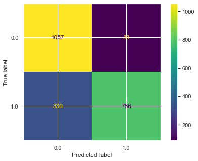

```python
sns.set(rc={'figure.figsize':(7,5)})
plot_confusion_matrix(ada,xtest,ytest)
plt.show()
```

```python
print(classification_report(ytest,y_predict5))
```

```
              precision    recall  f1-score   support

         0.0       0.76      0.92      0.83      1145
         1.0       0.90      0.70      0.79      1116

    accuracy                           0.82      2261
   macro avg       0.83      0.81      0.81      2261
weighted avg       0.83      0.82      0.81      2261
```

# Gradient Boosting Classifier

```python
gbc=GradientBoostingClassifier(n_estimators=50,random_state=69)
```

```python
gbc.fit(xtrain,ytrain)
```

```
GradientBoostingClassifier(n_estimators=50, random_state=69)
```

```python
y_predgbc=gbc.predict(xtest)
```

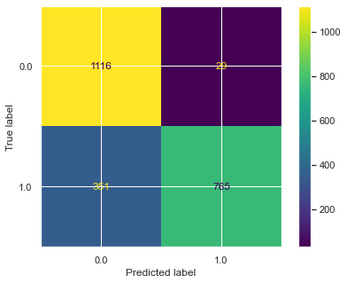

```python
sns.set(rc={'figure.figsize':(7,5)})
plot_confusion_matrix(gbc,xtest,ytest)
plt.show()
```

```python
print(classification_report(ytest,y_predgbc))
```

```
              precision    recall  f1-score   support

         0.0       0.76      0.97      0.85      1145
         1.0       0.96      0.69      0.80      1116

    accuracy                           0.83      2261
   macro avg       0.86      0.83      0.83      2261
weighted avg       0.86      0.83      0.83      2261
```

# Cross Validation Score

```python
from sklearn.model_selection import cross_val_score, StratifiedKFold
```

### Logistic regression model performance using cross_val_score

```python
cross_val_score(LogisticRegression(solver='liblinear',multi_class='ovr'), x, y,cv=5)
```

```
array([0.49900464, 0.67684141, 0.82614466, 0.91506304, 0.53585657])
```

### random forest performance using cross_val_score

```python
cross_val_score(RandomForestClassifier(n_estimators=100),x,y,cv=5)
```

```
array([0.55076311, 0.63901792, 0.85666888, 0.89051095, 0.59893758])
```

### DecisionTree performance using cross_val_score

```python
cross_val_score(DecisionTreeClassifier(),x,y,cv=5)
```

```
array([0.54412741, 0.61114798, 0.79296616, 0.81021898, 0.61952191])
```

### AdaBoost performance using cross_val_score

```python
cross_val_score(AdaBoostClassifier(),x,y,cv=5)
```

```
array([0.50630392, 0.63105508, 0.75580624, 0.91904446, 0.54780876])
```

### KNN performance using cross_val_score

```python
cross_val_score(KNeighborsClassifier(),x,y,cv=5)
```

```
array([0.52289317, 0.61048441, 0.82548109, 0.84804247, 0.60358566])
```

### GradientBoosting performance using cross_val_score

```python
cross_val_score(GradientBoostingClassifier(),x,y,cv=5)
```

```
array([0.50630392, 0.63901792, 0.81353683, 0.90577306, 0.56706507])
```

# Observations

- As per the avg results of different Algorithem models we can conclude the best performing Algorithems for this dataset is "Random Forest Classifer " & "Gradient Boosting Classifier".  
  we can see the following results: (i)Random Forest Classifer : Results: precision recall f1-score support

  ```
     0.0       0.80      0.90      0.85      1145
     1.0       0.88      0.77      0.82      1116
  ```

  accuracy 0.84 2261 macro avg 0.84 0.84 0.84 2261 weighted avg 0.84 0.84 0.84 2261

Cross Validation Score: [0.55076311, 0.63901792, 0.85666888, 0.89051095, 0.59893758]

(ii)Gradient Boosting Classifier: precision recall f1-score support

```
     0.0       0.76      0.97      0.85      1145
     1.0       0.96      0.69      0.80      1116

accuracy                           0.83      2261
```

macro avg 0.86 0.83 0.83 2261 weighted avg 0.86 0.83 0.83 2261

Cross Validation Score: [0.50630392, 0.63901792, 0.81353683, 0.90577306, 0.56706507]

# Recomendations:

States from Jharkhand, TamilNadu, Maharashtra & Karnataka Contributing highest no of loan defaulters. Self employed are contributing more no. of Loan Defaulters. And Self employed from East region and Salaried from South Region contributing highest no. of Load Defaulters. Company has take more precautionary measures in to these states and type of people.